# **Music Recommendation System**

## **Problem Definition**

### **The Context:**

- Why is this problem important to solve?

Recommendation systems are vital for any system to keep the users active and also to grow the user base which in turn will increase the usabilty result in profit increase

In the current dataset we have many users who are not active and having a recommendation system will help in recommending relavent songs to users which can help increasing user activty

### **The objective:**

- What is the intended goal?

The intended goal is to identify relavent songs that can be rewcommended to all users to increase user activty in the platform

### **The key questions:**

- What are the key questions that need to be answered?

Can we use the existing dataset to bring meaningful recommendation?

What model is best suited for the dataset in hand?

Is there a way to use output of multiple model for final design?

### **The problem formulation**:

- What is it that we are trying to solve using data science?

We are trying to indentify relavent songs that we can recommend to users based on user or item similarity, popularty of items (songs) using avaiable recommendation models

## **Data Dictionary**

The core data is the Taste Profile Subset released by the Echo Nest as part of the Million Song Dataset. There are two files in this dataset. The first file contains the details about the song id, titles, release, artist name, and the year of release. The second file contains the user id, song id, and the play count of users.

**song_data**

- song_id - A unique id given to every song
- title - Title of the song
- Release - Name of the released album
- Artist_name - Name of the artist
- year - Year of release

**count_data**

- user _id - A unique id given to the user
- song_id - A unique id given to the song
- play_count - Number of times the song was played

## **Data Source**

http://millionsongdataset.com/

### **Importing Libraries and the Dataset**

```python
# Mounting the drive
from google.colab import drive
drive.mount('/content/drive')
```

```python
# Used to ignore the warning given as output of the code
import warnings
warnings.filterwarnings('ignore')

# Basic libraries of python for numeric and dataframe computations
import numpy as np
import pandas as pd

# Import Matplotlib the Basic library for data visualization
import matplotlib.pyplot as plt

# Import seaborn - Slightly advanced library for data visualization
import seaborn as sns

# Import the required library to compute the cosine similarity between two vectors
from sklearn.metrics.pairwise import cosine_similarity

# Import defaultdict from collections A dictionary output that does not raise a key error
from collections import defaultdict

# Impoort mean_squared_error : a performance metrics in sklearn
from sklearn.metrics import mean_squared_error
```

### **Load the dataset**

```python
# Importing the datasets
song_df = pd.read_csv('/content/song_data.csv')
count_df = pd.read_csv('/content/count_data.csv')
```

```python
song_df.shape
```

```
(1000000, 5)
```

```python
count_df.shape
```

```
(2000000, 4)
```

### **Understanding the data by viewing a few observations**

```python
# Display first 10 records of count_df data
count_df.head(10)
```

|  | Unnamed: 0 | user_id | song_id | play_count |
| --- | --- | --- | --- | --- |
| 0 | 0 | b80344d063b5ccb3212f76538f3d9e43d87dca9e | SOAKIMP12A8C130995 | 1 |
| 1 | 1 | b80344d063b5ccb3212f76538f3d9e43d87dca9e | SOBBMDR12A8C13253B | 2 |
| 2 | 2 | b80344d063b5ccb3212f76538f3d9e43d87dca9e | SOBXHDL12A81C204C0 | 1 |
| 3 | 3 | b80344d063b5ccb3212f76538f3d9e43d87dca9e | SOBYHAJ12A6701BF1D | 1 |
| 4 | 4 | b80344d063b5ccb3212f76538f3d9e43d87dca9e | SODACBL12A8C13C273 | 1 |
| 5 | 5 | b80344d063b5ccb3212f76538f3d9e43d87dca9e | SODDNQT12A6D4F5F7E | 5 |
| 6 | 6 | b80344d063b5ccb3212f76538f3d9e43d87dca9e | SODXRTY12AB0180F3B | 1 |
| 7 | 7 | b80344d063b5ccb3212f76538f3d9e43d87dca9e | SOFGUAY12AB017B0A8 | 1 |
| 8 | 8 | b80344d063b5ccb3212f76538f3d9e43d87dca9e | SOFRQTD12A81C233C0 | 1 |
| 9 | 9 | b80344d063b5ccb3212f76538f3d9e43d87dca9e | SOHQWYZ12A6D4FA701 | 1 |

```python
# Display first 10 records of song_df data
song_df.head(10)
```

|  | song_id | title | release | artist_name | year |
| --- | --- | --- | --- | --- | --- |
| 0 | SOQMMHC12AB0180CB8 | Silent Night | Monster Ballads X-Mas | Faster Pussy cat | 2003 |
| 1 | SOVFVAK12A8C1350D9 | Tanssi vaan | Karkuteillä | Karkkiautomaatti | 1995 |
| 2 | SOGTUKN12AB017F4F1 | No One Could Ever | Butter | Hudson Mohawke | 2006 |
| 3 | SOBNYVR12A8C13558C | Si Vos Querés | De Culo | Yerba Brava | 2003 |
| 4 | SOHSBXH12A8C13B0DF | Tangle Of Aspens | Rene Ablaze Presents Winter Sessions | Der Mystic | 0 |
| 5 | SOZVAPQ12A8C13B63C | Symphony No. 1 G minor "Sinfonie Serieuse"/All... | Berwald: Symphonies Nos. 1/2/3/4 | David Montgomery | 0 |
| 6 | SOQVRHI12A6D4FB2D7 | We Have Got Love | Strictly The Best Vol. 34 | Sasha / Turbulence | 0 |
| 7 | SOEYRFT12AB018936C | 2 Da Beat Ch'yall | Da Bomb | Kris Kross | 1993 |
| 8 | SOPMIYT12A6D4F851E | Goodbye | Danny Boy | Joseph Locke | 0 |
| 9 | SOJCFMH12A8C13B0C2 | Mama_ mama can't you see ? | March to cadence with the US marines | The Sun Harbor's Chorus-Documentary Recordings | 0 |

### **Let us check the data types and and missing values of each column**

```python
# Display info of count_df
count_df.info()
```

```
<class 'pandas.core.frame.DataFrame'>
RangeIndex: 2000000 entries, 0 to 1999999
Data columns (total 4 columns):
 #   Column      Dtype
---  ------      -----
 0   Unnamed: 0  int64
 1   user_id     object
 2   song_id     object
 3   play_count  int64
dtypes: int64(2), object(2)
memory usage: 61.0+ MB
```

```python
count_df.isnull().sum().sum()
```

```
0
```

```python
# Display info of song_df
song_df.info()
```

```
<class 'pandas.core.frame.DataFrame'>
RangeIndex: 1000000 entries, 0 to 999999
Data columns (total 5 columns):
 #   Column       Non-Null Count    Dtype
---  ------       --------------    -----
 0   song_id      1000000 non-null  object
 1   title        999983 non-null   object
 2   release      999993 non-null   object
 3   artist_name  1000000 non-null  object
 4   year         1000000 non-null  int64
dtypes: int64(1), object(4)
memory usage: 38.1+ MB
```

```python
song_df.isnull().sum().sum() #There are 24 missing data in the song_df dataframe
```

```
24
```

```python
song_df.isnull().sum()
```

|  | 0 |
| --- | --- |
| song_id | 0 |
| title | 17 |
| release | 7 |
| artist_name | 0 |
| year | 0 |

**dtype:** int64

#### **Observations and Insights:**

There are 17 missing titles and 7 release in the song_df dataframe

```python
# Left merge count_df and song_df on "song_id". Drop duplicates from song_df data simultaneously
df = pd.merge(count_df, song_df.drop_duplicates(), on='song_id', how='left')
# Drop the column 'Unnamed: 0'
df.drop('Unnamed: 0', axis=1, inplace=True)
## Name the obtained dataframe as "df"
df.shape
```

```
(2054534, 7)
```

```python
df.info()
```

```
<class 'pandas.core.frame.DataFrame'>
RangeIndex: 2054534 entries, 0 to 2054533
Data columns (total 7 columns):
 #   Column       Dtype
---  ------       -----
 0   user_id      object
 1   song_id      object
 2   play_count   int64
 3   title        object
 4   release      object
 5   artist_name  object
 6   year         int64
dtypes: int64(2), object(5)
memory usage: 109.7+ MB
```

```python
df.isnull().sum().sum()
```

```
0
```

**Observation** After performing left join with count_df the final dataframe has no null values

**Think About It:** As the user_id and song_id are encrypted. Can they be encoded to numeric features?

```python
# Apply label encoding for "user_id" and "song_id"
from sklearn.preprocessing import LabelEncoder
df_lb = df[['user_id','song_id']].apply(LabelEncoder().fit_transform)
```

```python
df_lb[['play_count','title','release','artist_name','year']] = df[['play_count','title','release','artist_name','year']] #Adding play_count, title, release, artist_name, year to the encoded user_id and song_id
```

```python
df_lb.head()
```

|  | user_id | song_id | play_count | title | release | artist_name | year |
| --- | --- | --- | --- | --- | --- | --- | --- |
| 0 | 54961 | 153 | 1 | The Cove | Thicker Than Water | Jack Johnson | 0 |
| 1 | 54961 | 413 | 2 | Entre Dos Aguas | Flamenco Para Niños | Paco De Lucia | 1976 |
| 2 | 54961 | 736 | 1 | Stronger | Graduation | Kanye West | 2007 |
| 3 | 54961 | 750 | 1 | Constellations | In Between Dreams | Jack Johnson | 2005 |
| 4 | 54961 | 1188 | 1 | Learn To Fly | There Is Nothing Left To Lose | Foo Fighters | 1999 |

```python
df = df_lb
```

```python
df.shape
```

```
(2054534, 7)
```

**Think About It:** As the data also contains users who have listened to very few songs and vice versa, is it required to filter the data so that it contains users who have listened to a good count of songs and vice versa?

A dataset of size 2000000 rows x 7 columns can be quite large and may require a lot of computing resources to process. This can lead to long processing times and can make it difficult to train and evaluate your model efficiently. In order to address this issue, it may be necessary to trim down your dataset to a more manageable size.

```python
# Get the column containing the users
users = df.user_id

# Create a dictionary that maps users(listeners) to the number of songs that they have listened to
playing_count = dict()

for user in users:
    # If we already have the user, just add 1 to their playing count
    if user in playing_count:
        playing_count[user] += 1

    # Otherwise, set their playing count to 1
    else:
        playing_count[user] = 1
```

```python
# We want our users to have listened at least 90 songs
SONG_COUNT_CUTOFF = 90

# Create a list of users who need to be removed
remove_users = []

for user, num_songs in playing_count.items():

    if num_songs < SONG_COUNT_CUTOFF:
        remove_users.append(user)

df = df.loc[ ~ df.user_id.isin(remove_users)]
```

```python
# Get the column containing the songs
songs = df.song_id

# Create a dictionary that maps songs to its number of users(listeners)
playing_count = dict()

for song in songs:
    # If we already have the song, just add 1 to their playing count
    if song in playing_count:
        playing_count[song] += 1

    # Otherwise, set their playing count to 1
    else:
        playing_count[song] = 1
```

```python
# We want our song to be listened by atleast 120 users to be considred
LISTENER_COUNT_CUTOFF = 120

remove_songs = []

for song, num_users in playing_count.items():
    if num_users < LISTENER_COUNT_CUTOFF:
        remove_songs.append(song)

df_final= df.loc[ ~ df.song_id.isin(remove_songs)]
```

Out of all the songs available, songs with play_count less than or equal to 5 are in almost 90% abundance. So for building the recommendation system let us consider only those songs.

```python
# Keep only records of songs with play_count less than or equal to (<=) 5
df_final = df_final[df_final.play_count<=5]
```

```python
# Check the shape of the data
df_final.shape
```

```
(138301, 7)
```

**Observation** The final dataset that will be used to run the models have 138301 rows and 7 columns

```python
df_final.head()
```

|  | user_id | song_id | play_count | title | release | artist_name | year |
| --- | --- | --- | --- | --- | --- | --- | --- |
| 206 | 6958 | 447 | 1 | Daisy And Prudence | Distillation | Erin McKeown | 2000 |
| 208 | 6958 | 512 | 1 | The Ballad of Michael Valentine | Sawdust | The Killers | 2004 |
| 209 | 6958 | 549 | 1 | I Stand Corrected (Album) | Vampire Weekend | Vampire Weekend | 2007 |
| 210 | 6958 | 703 | 1 | They Might Follow You | Tiny Vipers | Tiny Vipers | 2007 |
| 211 | 6958 | 719 | 1 | Monkey Man | You Know I'm No Good | Amy Winehouse | 2007 |

## **Exploratory Data Analysis**

### **Let's check the total number of unique users, songs, artists in the data**

Total number of unique user id

```python
# Display total number of unique user_id
df_final.user_id.nunique()
```

```
3337
```

Total number of unique song id

```python
# Display total number of unique song_id
df_final.song_id.nunique()
```

```
620
```

Total number of unique artists

```python
# Display total number of unique artists
df_final.artist_name.nunique()
```

```
247
```

#### **Observations and Insights:**

Below are the findings,

There are **3337** unique users in the final dataset with **620** unique songs and **247** unique artists. That is 2.5 songs per artist approximately

### **Let's find out about the most interacted songs and interacted users**

Most interacted songs

```python
df_final['song_id'].value_counts().head(10) #Top 10 songs based on play count
```

| song_id | count |
| --- | --- |
| 8582 | 1602 |
| 6293 | 1264 |
| 3567 | 982 |
| 4270 | 960 |
| 1286 | 920 |
| 7796 | 910 |
| 310 | 902 |
| 7998 | 820 |
| 352 | 802 |
| 2220 | 767 |

**dtype:** int64

Most interacted users

```python
df_final['user_id'].value_counts().head(10) #top 10 active users based on play count
```

| user_id | count |
| --- | --- |
| 61472 | 282 |
| 15733 | 240 |
| 37049 | 237 |
| 9570 | 204 |
| 10763 | 199 |
| 23337 | 196 |
| 75144 | 194 |
| 43041 | 193 |
| 26616 | 191 |
| 9097 | 190 |

**dtype:** int64

#### **Observations and Insights:**

- Song_Id 8582 and 6293 has the maximum number of play count as 1602 and 1264 respectively followed by Song_Id 3567 with 982 play count
- Unser_Id 61472 has the most number of play count which is 282 followed by 15733 and 37049 with 240 and 237 play counts

Songs released on yearly basis

```python
# Find out the number of songs released in a year, use the songs_df
# Hint: Use groupby function on the 'year' column
song_df.groupby('year')['song_id'].nunique()
```

| year | song_id |
| --- | --- |
| 0 | 484310 |
| 1922 | 6 |
| 1924 | 5 |
| 1925 | 7 |
| 1926 | 19 |
| ... | ... |
| 2007 | 39342 |
| 2008 | 34689 |
| 2009 | 30969 |
| 2010 | 9382 |
| 2011 | 1 |

90 rows × 1 columns

**dtype:** int64

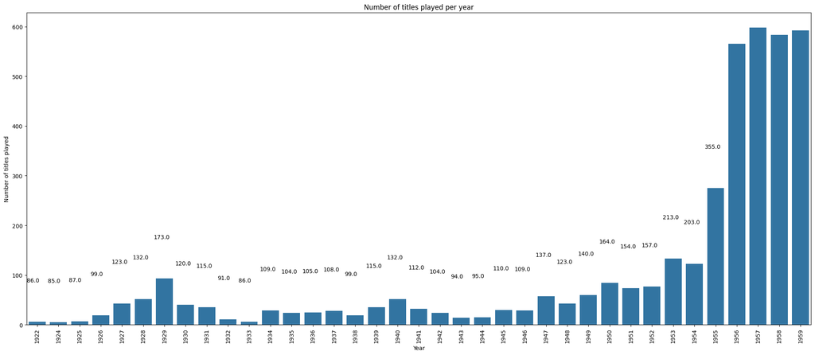

```python
# Set the figure size
plt.figure(figsize=(25,10))

song_df_plot = song_df.loc[(song_df['year'] > 0) & (song_df['year'] < 1960),['song_id', 'title',	'release', 'artist_name',	'year']]
# Create a barplot plot with y label as "number of titles played" and x -axis year
ax = sns.barplot(x=song_df_plot.year.value_counts().index, y=song_df_plot.year.value_counts())

# Set the x label of the plot
ax.set_xlabel('Year')
# Set the y label of the plot
ax.set_ylabel('Number of titles played')
# Set the title of the plot
ax.set_title('Number of titles played per year')

ax.set_xticklabels(ax.get_xticklabels(), rotation=90)

for i in range(len(ax.patches)):
  x=ax.patches[i].get_x() + ax.patches[i].get_width()/2-0.5
  y=ax.patches[i].get_height() + 80
  ax.annotate((y), (x,y))

# Show the plot
```

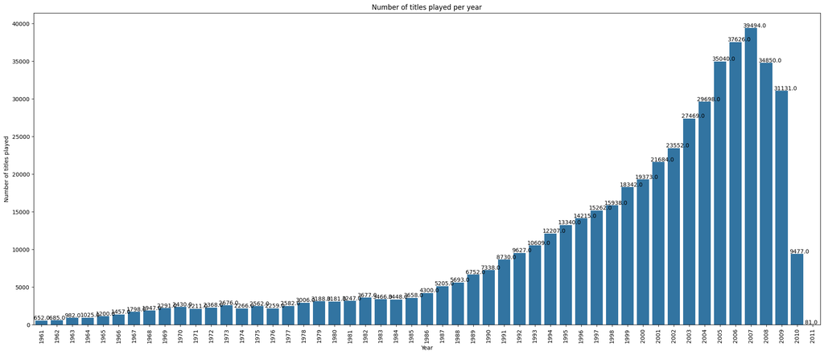

```python
# Set the figure size
plt.figure(figsize=(25,10))

song_df_plot = song_df.loc[song_df['year'] > 1960,['song_id', 'title',	'release', 'artist_name',	'year']]
# Create a barplot plot with y label as "number of titles played" and x -axis year
ax = sns.barplot(x=song_df_plot.year.value_counts().index, y=song_df_plot.year.value_counts())

# Set the x label of the plot
ax.set_xlabel('Year')
# Set the y label of the plot
ax.set_ylabel('Number of titles played')
# Set the title of the plot
ax.set_title('Number of titles played per year')

ax.set_xticklabels(ax.get_xticklabels(), rotation=90)

for i in range(len(ax.patches)):
  x=ax.patches[i].get_x() + ax.patches[i].get_width()/2-0.5
  y=ax.patches[i].get_height() + 80
  ax.annotate((y), (x,y))

# Show the plot
```

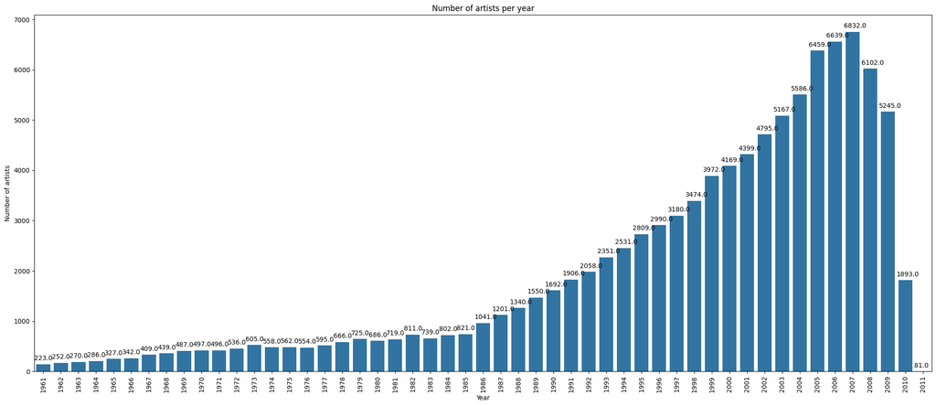

```python
# Set the figure size
plt.figure(figsize=(25, 10))

song_df_artist = song_df.loc[song_df['year'] > 1960, ['artist_name', 'year']]

# Group by year and count unique titles
artist_counts_per_year = song_df_artist.groupby('year')['artist_name'].nunique()

# Create a barplot
ax = sns.barplot(x=artist_counts_per_year.index, y=artist_counts_per_year.values)

# Set the x label of the plot
ax.set_xlabel('Year')
# Set the y label of the plot
ax.set_ylabel('Number of artists')
# Set the title of the plot
ax.set_title('Number of artists per year')

ax.set_xticklabels(ax.get_xticklabels(), rotation=90)

for i in range(len(ax.patches)):
  x = ax.patches[i].get_x() + ax.patches[i].get_width() / 2 - 0.5
  y = ax.patches[i].get_height() + 80
  ax.annotate((y), (x, y))

# Show the plot
plt.show() # Added plt.show() to display the plot
```

```python
artist_counts_per_year
```

| year | artist_name |
| --- | --- |
| 1961 | 143 |
| 1962 | 172 |
| 1963 | 190 |
| 1964 | 206 |
| 1965 | 247 |
| 1966 | 262 |
| 1967 | 329 |
| 1968 | 359 |
| 1969 | 407 |
| 1970 | 417 |
| 1971 | 416 |
| 1972 | 456 |
| 1973 | 525 |
| 1974 | 478 |
| 1975 | 482 |
| 1976 | 474 |
| 1977 | 515 |
| 1978 | 586 |
| 1979 | 645 |
| 1980 | 606 |
| 1981 | 639 |
| 1982 | 731 |
| 1983 | 659 |
| 1984 | 722 |
| 1985 | 741 |
| 1986 | 961 |
| 1987 | 1121 |
| 1988 | 1260 |
| 1989 | 1470 |
| 1990 | 1612 |
| 1991 | 1826 |
| 1992 | 1978 |
| 1993 | 2271 |
| 1994 | 2451 |
| 1995 | 2729 |
| 1996 | 2910 |
| 1997 | 3100 |
| 1998 | 3394 |
| 1999 | 3892 |
| 2000 | 4089 |
| 2001 | 4319 |
| 2002 | 4715 |
| 2003 | 5087 |
| 2004 | 5506 |
| 2005 | 6379 |
| 2006 | 6559 |
| 2007 | 6752 |
| 2008 | 6022 |
| 2009 | 5165 |
| 2010 | 1813 |
| 2011 | 1 |

**dtype:** int64

#### **Observations and Insights:**

**Think About It:** What other insights can be drawn using exploratory data analysis?

Now that we have explored the data, let's apply different algorithms to build recommendation systems.

**Note:** Use the shorter version of the data, i.e., the data after the cutoffs as used in Milestone 1.

## Building various models

### **Popularity-Based Recommendation Systems**

Let's take the count and sum of play counts of the songs and build the popularity recommendation systems based on the sum of play counts.

```python
# Calculating average play_count
       # Hint: Use groupby function on the song_id column
avg_play_time = df_final.groupby('song_id')['play_count'].mean()
# Calculating the frequency a song is played
      # Hint: Use groupby function on the song_id column
song_freq_count = df_final.groupby('song_id')['play_count'].count()
```

```python
# Making a dataframe with the average_count and play_freq
df_final_count = pd.merge(avg_play_time, song_freq_count, on='song_id')

df_final_count.columns = ['avg_play_count', 'song_freq_count']
df_final_count.sort_values(by = 'avg_play_count', ascending = False, inplace = True)
# Let us see the first five records of the final_play dataset
df_final_count.head(5)
```

| song_id | avg_play_count | song_freq_count |
| --- | --- | --- |
| 7224 | 3.366972 | 109 |
| 6450 | 2.618182 | 110 |
| 8324 | 2.611650 | 103 |
| 9942 | 2.484277 | 159 |
| 8483 | 2.307692 | 130 |

Now, let's create a function to find the top n songs for a recommendation based on the average play count of song. We can also add a threshold for a minimum number of playcounts for a song to be considered for recommendation.

```python
# Build the function to find top n songs
def top_n_songs(data, n, min_interactions, sort_order, sort_by):
  # Sorting values with respect to average rating
  recommendations = data[data.song_freq_count >= min_interactions] #filtering data for rating count greater than min_interactions input variable
 #below if else statement is used to sort the dataframe by using sort_order and sort_by input variable
  if sort_order == 'desc':
    if sort_by == 'avg_play_count':
      recommendations = recommendations.sort_values(by = 'avg_play_count', ascending = False)
    else:
      recommendations = recommendations.sort_values(by = 'song_freq_count', ascending = False)
    recommendations = recommendations.head(n) #returning the top n rows as per input variable
  else:
    if sort_by == 'avg_play_count':
      recommendations = recommendations.sort_values(by = 'avg_play_count', ascending = True)
    else:
      recommendations = recommendations.sort_values(by = 'song_freq_count', ascending = True)
    recommendations = recommendations.head(n) #returning the top n rows as per input variable
  return recommendations
```

```python
# Recommend top 10 songs using the function defined above
top_n_songs(data = df_final_count, n = 10, min_interactions = 1, sort_order = 'desc', sort_by = 'avg_play_count') #Top 10 songs order by average play count descending
```

| song_id | avg_play_count | song_freq_count |
| --- | --- | --- |
| 7224 | 3.366972 | 109 |
| 6450 | 2.618182 | 110 |
| 8324 | 2.611650 | 103 |
| 9942 | 2.484277 | 159 |
| 8483 | 2.307692 | 130 |
| 5531 | 2.305723 | 664 |
| 657 | 2.283019 | 159 |
| 5653 | 2.272727 | 110 |
| 614 | 2.236908 | 401 |
| 2220 | 2.205997 | 767 |

### **User User Similarity-Based Collaborative Filtering**

To build the user-user-similarity-based and subsequent models we will use the "surprise" library.

```python
# Install the surprise package using pip. Uncomment and run the below code to do the same

!pip install surprise #Installing surprise library which has most of the commom recommendation system packages
```

```
     ━━━━━━━━━━━━━━━━━━━━━━━━━━━━━━━━━━━━━━━━ 154.4/154.4 kB 6.5 MB/s eta 0:00:00
  Installing build dependencies ... done
  Getting requirements to build wheel ... done
  Preparing metadata (pyproject.toml) ... done
Downloading surprise-0.1-py2.py3-none-any.whl (1.8 kB)
```

```python
# Import necessary libraries

# To compute the accuracy of models
from surprise import accuracy

# This class is used to parse a file containing play_counts, data should be in structure - user; item; play_count
from surprise.reader import Reader

# Class for loading datasets
from surprise.dataset import Dataset

# For tuning model hyperparameters
from surprise.model_selection import GridSearchCV

# For splitting the data in train and test dataset
from surprise.model_selection import train_test_split

# For implementing similarity-based recommendation system
from surprise.prediction_algorithms.knns import KNNBasic

# For implementing matrix factorization based recommendation system
from surprise.prediction_algorithms.matrix_factorization import SVD

# For implementing KFold cross-validation
from surprise.model_selection import KFold

# For implementing clustering-based recommendation system
from surprise import CoClustering
```